```python
import pandas as pd
import numpy as np
import matplotlib.pyplot as plt
import seaborn as sns

from collections import Counter
import itertools

from IPython.display import clear_output
from IPython.display import HTML

from sklearn.model_selection import train_test_split
from sklearn.neighbors import KNeighborsRegressor
from sklearn.linear_model import LinearRegression
from sklearn.linear_model import Lasso
from sklearn.linear_model import Ridge
from sklearn.preprocessing import MinMaxScaler
from sklearn.preprocessing import StandardScaler
from sklearn.model_selection import GridSearchCV

import xgboost
from xgboost import XGBRegressor
```

```python
import sys
sys.path.append('../judeml')
sys.path.append('../concretenl')

from judeml.regression.automate import Regressor
from concretenl.config import data_path
```

# Formulating the Optimum Concrete Mix Using Machine Learning

By **Oonre Advincula-Go**

## Executive Summary

Concrete is all around us and is an integral part of our world.

Using data from the UCI ML Repository that contains information on the ingredients in concrete mixes as well as their tested compressive strengths, we want to predict the compressive strength of a new concrete mix based only from its ingredients.

Exploratory data analysis was done - pair plots were made and it was determined that among the ingredients of a concrete mix, cement has the greatest effect on concrete compressive strength. Different regression algorithms were benchmarked and the best algorithm was determine to be Gradient Boosting. Since GBM was already determined to provide the best accuracy, XGBoost was used and provided even better results than GBM. The highest accuracy obtained using XGBoost was 93.66% (averaged over 10 trials with different train-test splits).

In order to formulate the optimum concrete mix, the prices for each ingredient were be canvassed, and a brute-force iteration method was tried, where all possible concrete mixes were to be entered into the model, and the predicted strength of each taken. The optimum concrete mix is the formulation that yields a desired strength for a minimum price. However, this method failed due to the sheer number of possible permutations - iterating through them all would take several lifetimes. Thus, the data was revisited and the optimum concrete mix was taken from the samples.

To obtain a compressive strength of 40 MPa (this is the threshold of high-strength concrete), the optimum concrete mix was found to be:

- cement: 139.6kg
- slag: 209.4kg
- flyash: 0.0kg
- water: 192.0kg
- superplasticizer: 0.0kg
- coarseaggregate: 1047.0kg
- fineaggregate: 806.9kg

which obtained a strength of 44.7 MPa, for a price of P2304.50 per cubic meter (yields 19.40 KPa per peso).

## 1. Introduction

A vast majority of structures today are built chiefly from concrete. The very floor you step on, though it may be laid with tiles or some other material, is underlain by concrete. The walls that surround you, the columns that hold them up, even the driveways and roads outside are all made of concrete. It is thus integral to modern human life.

### 1.1 Components of a Concrete Mixture

[figure not shown]

Since we now know that concrete is composed of a variety of materials, which altogether make up the concrete mix. Among these ingredients, only cement, water, and aggregates are essential, but proportioning these ingredients differently can yield a wide range of results. Concrete takes about 28 days of hardening to achieve most of its full strength. Though it still continues to harden after that, strength gained after 28 days is negligible and marginal.

#### Ingredients

- Cement - usually *Portland cement*, a limestone-based powder that serves as a binder. As a trivia, Portland cement is not named for the city of Portland, Oregon in the United States, but for a kind of quarry stone known as *Portland stone* from the Isle of Portland, Dorset, UK. Portland cement is thought to resemble this stone.
- Water - when mixed with Portland cement, the two undergo a chemical reaction known as *hydration*, in which the major compounds in cement form chemical bonds with water molecules.
- Aggregates - particulate material that provide the strength and hardness to the concrete.
  - Coarse Aggregate - gravel
  - Fine Aggregate - sand
- Admixtures - chemicals that are added to the concrete mix to impart some desired properties or modifications. Some admixtures are used to speed up concrete curing or hardening, some are used to slow down the same process, others are used to reduce the required amount of water for the mix, and yet others are used to make the concrete mix highly fluid and easily workable (easy to mix). This last type of admixture I have mentioned is known as a *superplasticizer*. Admixtures are optional.

### 1.2 Compressive Strength

Concrete is used because of its high *compressive strength* - the ability to bear crushing load without giving way. For concrete, compressive strength is usually measured in MegaPascals (MPa), which is weight in Newtons that concrete can bear per square millimeter of its area.

To measure the strength of a concrete mix, some amount of the freshly poured concrete is placed in a cylindrical mold, which is then hardened, typically for 28 days. The concrete cylinder is then taken out of its mold and crushed. The pressure required to crush the cylinder is logged as the concrete's compressive strength. One can immediately see the disadvantage in measuring concrete strength by this method - it will take 28 days to know the strength of the concrete, by which time it will be too late to easily rectify any mistakes if the concrete is found to be substandard.

### 1.3 Objectives of the Study

As stated above, the current method of measuring concrete strength is disadvantageous mainly because of the 28-day delay. As an example, I want to pour concrete for the 12th floor of my building. I do so, and also take some of the mix and mold it into cylinders. 28 days later, I find out that the concrete crushed at 30 MPa, when the design called for 40 MPa. I have several courses of action at this point, none of which are easy to implement. These choices include retrofitting at best, and in a worst-case scenario, demolishing the newly-built level and redoing the work.

1. Using data on the ingredients of a concrete mix, we want to be able to reliably predict the compressive strength of a concrete mix, without waiting 28 days just to crush it.
2. By creating an accurate regression model, we want to optimize the cheapest possible concrete mix that can achieve a desired compressive strength (an example is 40 MPa, which is the minimum for high-strength concrete).

### 1.4 Limitation of the Study

Concrete strength is not solely dependent on its ingredients - there are multiple factors and externalities that can affect the final strength, such as poor mixing practices and the ambient temperature, among others. There will always be error unexplainable by the data.

### 1.5 Summary of the Methodology

1. Data Reading and Preprocessing
   - The data will be opened and checked for completeness, if it will need cleaning and preprocessing.
   - The features will be analyzed and discussed.
2. Exploratory Data Analysis
   - Pair plots will be done to determine relationships between variables, or between variables and the target.
   - Correlations to determine if features are independent and whether some of them may be dropped.
3. Machine Learning
   - Different regression algorithms will be benchmarked using Jude's Automated System to determine the best algorithm to use.
   - The hyperparameters of the best algorithm will be tuned using GridSearchCV.
   - The objective of this section is to predict the compressive strength of a concrete mix to as high an accuracy as possible.
4. Formulating the Optimum Concrete Mix
   - Prices for each ingredient will be canvassed
   - A brute-force iteration method will be tried, where all possible concrete mixes will be entered into the model, and the predicted strength of each taken. The optimum concrete mix is the formulation that yields a desired strength for a minimum price. However, this method may fail due to the sheer number of possible permutations.

## 2. Data

### 2.1 Reading the Data

```python
df = pd.read_csv(data_path)
df.head()
```

|  | cement | slag | flyash | water | superplasticizer | coarseaggregate | fineaggregate | age | csMPa |
| --- | --- | --- | --- | --- | --- | --- | --- | --- | --- |
| 0 | 540.0 | 0.0 | 0.0 | 162.0 | 2.5 | 1040.0 | 676.0 | 28 | 79.99 |
| 1 | 540.0 | 0.0 | 0.0 | 162.0 | 2.5 | 1055.0 | 676.0 | 28 | 61.89 |
| 2 | 332.5 | 142.5 | 0.0 | 228.0 | 0.0 | 932.0 | 594.0 | 270 | 40.27 |
| 3 | 332.5 | 142.5 | 0.0 | 228.0 | 0.0 | 932.0 | 594.0 | 365 | 41.05 |
| 4 | 198.6 | 132.4 | 0.0 | 192.0 | 0.0 | 978.4 | 825.5 | 360 | 44.30 |

```python
df.shape
```

```
(1030, 9)
```

We have a 1030 x 9 DataFrame, with the target column being `csMPa`.

```python
df.isna().sum()
```

```
cement              0
slag                0
flyash              0
water               0
superplasticizer    0
coarseaggregate     0
fineaggregate       0
age                 0
csMPa               0
dtype: int64
```

Fortunately for us, the data is already clean, and there are no null values or placeholders. Thus, the data can be used directly (no need for preprocessing).

### 2.2 Data Features

Data was taken from Kaggle but is originally from the UCI Machine Learning Repository.

#### Features

The features of the data describe the number of kilograms of each ingredient per cubic meter of a concrete mixture.

| Name | Data Type | Measurement | Description |
| --- | --- | --- | --- |
| Cement (component 1) | quantitative | kg in a m3 mixture | Input Variable |
| Blast Furnace Slag (component 2) | quantitative | kg in a m3 mixture | Input Variable |
| Fly Ash (component 3) | quantitative | kg in a m3 mixture | Input Variable |
| Water (component 4) | quantitative | kg in a m3 mixture | Input Variable |
| Superplasticizer (component 5) | quantitative | kg in a m3 mixture | Input Variable |
| Coarse Aggregate (component 6) | quantitative | kg in a m3 mixture | Input Variable |
| Fine Aggregate (component 7) | quantitative | kg in a m3 mixture | Input Variable |
| Age | quantitative | Day (1~365) | Input Variable |
| Concrete compressive strength | quantitative | MPa | Output Variable |

Note that we now have two additional components not discussed earlier: Blast Furnace Slag and Fly Ash. Blast Furnace Slag is a by-product of iron/steel smelting, and, being cementitious, is thought to increase the strength of concrete if added.

Fly Ash is a particulate by-product of coal combustion. It is thought to have pozzolanic (cementitious) properties as well, adding to the strength of concrete. However, some dismiss fly ash as a filler or extender.

```python
df.describe()
```

|  | cement | slag | flyash | water | superplasticizer | coarseaggregate | fineaggregate | age | csMPa |
| --- | --- | --- | --- | --- | --- | --- | --- | --- | --- |
| count | 1030.000000 | 1030.000000 | 1030.000000 | 1030.000000 | 1030.000000 | 1030.000000 | 1030.000000 | 1030.000000 | 1030.000000 |
| mean | 281.167864 | 73.895825 | 54.188350 | 181.567282 | 6.204660 | 972.918932 | 773.580485 | 45.662136 | 35.817961 |
| std | 104.506364 | 86.279342 | 63.997004 | 21.354219 | 5.973841 | 77.753954 | 80.175980 | 63.169912 | 16.705742 |
| min | 102.000000 | 0.000000 | 0.000000 | 121.800000 | 0.000000 | 801.000000 | 594.000000 | 1.000000 | 2.330000 |
| 25% | 192.375000 | 0.000000 | 0.000000 | 164.900000 | 0.000000 | 932.000000 | 730.950000 | 7.000000 | 23.710000 |
| 50% | 272.900000 | 22.000000 | 0.000000 | 185.000000 | 6.400000 | 968.000000 | 779.500000 | 28.000000 | 34.445000 |
| 75% | 350.000000 | 142.950000 | 118.300000 | 192.000000 | 10.200000 | 1029.400000 | 824.000000 | 56.000000 | 46.135000 |
| max | 540.000000 | 359.400000 | 200.100000 | 247.000000 | 32.200000 | 1145.000000 | 992.600000 | 365.000000 | 82.600000 |

We see that the data distributions vary per column - some ingredients are added liberally to mixes such as coarse aggregate, and some are present in minimal amounts such as the superplasticizer. This is expected, since aggregate (sand and gravel) should make up the bulk of the concrete because it provides the concrete's bulk and hardness.

## 3. EDA

As with most analytics projects, an exploratory data analysis or EDA will be performed. EDA is very important to any data project as it allows a preliminary look not just into the data structure, but also into the data itself. We might learn about the distribution of each variable, or relationships between variables. These sometimes give us insights that can be helpful when performing Machine Learning.

### 3.1 The Target

The variable of interest in this dataset is the compressive strength - column `csMPa` in the DataFrame.

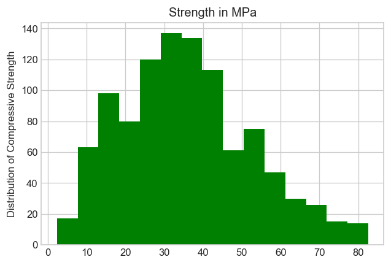

```python
plt.figure(dpi=120)
df['csMPa'].plot.hist(bins=15, color='green')
plt.ylabel('Distribution of Compressive Strength')
plt.title('Strength in MPa')
plt.show()
```

The spread is quite significant - we have some weak concrete at as low as 10 MPa or less, and some very high strength mixes at more than 80 MPa, which is the very upper limit of obtainable strength with concrete.

### 3.2 Pair Plots

In order to obtain a visualization of the relationships between variables as well as the distributions, it is appropriate to construct pair-wise plots, or "pair plots".

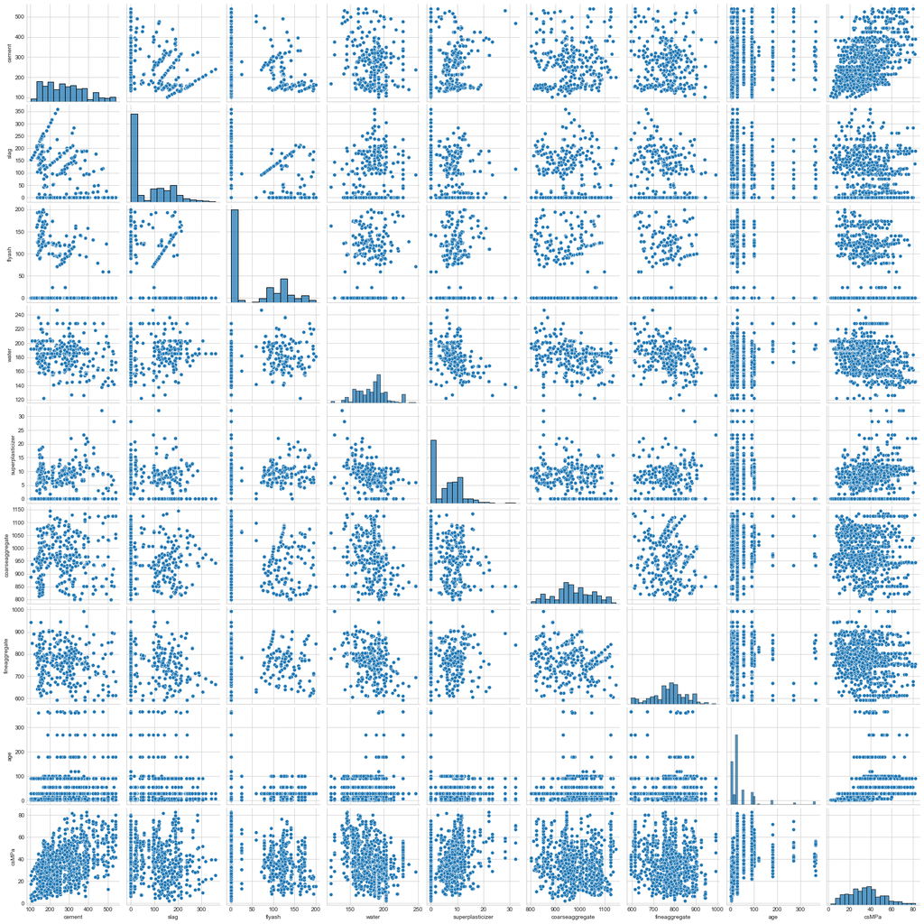

```python
prp = sns.pairplot(df)
```

Just by looking at the pair plots, it is difficult to spot relationships, as most of the features seem to be uncorrelated. However, we do see a weak positive trend between `cement` and `csMPa`.

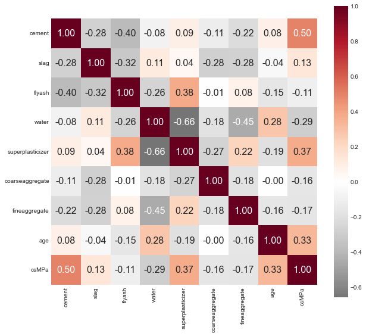

```python
plt.figure(figsize=(10, 9))
sns.heatmap((df.corr()), annot=True, annot_kws={"size": 16}, center=0, square=True, fmt='.2f', cmap='RdGy_r')
plt.show()
```

Strong relationships:

- `water` and `superplasticizer` - superplasticizer makes concrete more fluid and reduces the required water content. Thus, this is expected.
- `csMPa` and `cement` - moderately strong positive correlation. More cement means stronger concrete. This is also expected.

### 3.3 EDA Conclusion

Features need not be dropped since they are not too highly correlated so as to justify manual feature reduction.

## 4. Preparation of Data for Machine Learning

### 4.1 Feature Engineering

```python
df.head()
```

|  | cement | slag | flyash | water | superplasticizer | coarseaggregate | fineaggregate | age | csMPa |
| --- | --- | --- | --- | --- | --- | --- | --- | --- | --- |
| 0 | 540.0 | 0.0 | 0.0 | 162.0 | 2.5 | 1040.0 | 676.0 | 28 | 79.99 |
| 1 | 540.0 | 0.0 | 0.0 | 162.0 | 2.5 | 1055.0 | 676.0 | 28 | 61.89 |
| 2 | 332.5 | 142.5 | 0.0 | 228.0 | 0.0 | 932.0 | 594.0 | 270 | 40.27 |
| 3 | 332.5 | 142.5 | 0.0 | 228.0 | 0.0 | 932.0 | 594.0 | 365 | 41.05 |
| 4 | 198.6 | 132.4 | 0.0 | 192.0 | 0.0 | 978.4 | 825.5 | 360 | 44.30 |

The data is already clean, so we can proceed directly to feature engineering.

As stated in the introduction, aging cement beyond 28 days has a negligible effect on its strength. Thus, to reduce noise, we will replace the age of all samples above 28 days with 28.

```python
df_28 = df.copy()
df_28['age'] = df_28['age'].apply(lambda x: 28 if x > 28 else x)
```

### 4.2 Preparation of the Target Column and the Feature DataFrame

```python
target = df['csMPa']
df_features = df.drop(columns='csMPa')
```

```python
target_28 = df_28['csMPa']
df_features_28 = df_28.drop(columns='csMPa')
```